# Introduction to Text Analysis Using Tensorflow & Keras

Integrating R & Python

03 December 2019

# Overview

This tutorial walks through how to perform text analyses using Tensorflow by integrating Python and R. We start with an overview of the R package `reticulate` that allows us to seamlessly call Python from within R and pitch and catch objects between the languages.

## Using The `reticulate` R Package (reproduced from [**here**](https://rstudio.github.io/reticulate/#python-in-r-markdown))

The `reticulate` package provides a comprehensive set of tools for interoperability between Python and R. The package includes facilities for:

- Calling Python from R in a variety of ways including R Markdown, sourcing Python scripts, importing Python modules, and using Python interactively within an R session.
- Translation between R and Python objects (for example, between R and Pandas data frames, or between R matrices and NumPy arrays).
- Flexible binding to different versions of Python including virtual environments and Conda environments.

`reticulate` embeds a Python session within your R session, enabling seamless, high-performance interoperability. As an R developer that uses Python for some of your work or a member of data science team that uses both languages, `reticulate` can greatly streamline your workflow!

## Installation

Install the `reticulate` package from CRAN as follows:

```r
install.packages("reticulate")
```

By default, `reticulate` uses the version of Python found on your `PATH` (i.e. `Sys.which("python")`). The `reticulate::use_python()` function enables you to specify an alternate version, for example:

```r
reticulate::use_python("path/to/python.exe", required = T)
```

The `reticulate::use_virtualenv()` and `reticulate::use_condaenv()` functions enable you to specify versions of Python in virtual or Conda environments, for example: `reticulate::use_virtualenv("myenv")`. See [**this article**](https://rstudio.github.io/reticulate/articles/versions.html) for more details.

You can install any required Python packages using standard shell tools like `pip` and `conda`. Alternately, `reticulate` includes functions for managing and installing packages within virtual environments and Conda environments. See [**this article**](https://rstudio.github.io/reticulate/articles/python_packages.html) for more details.

## There are a variety of ways to integrate Python code into your R projects:

### Python in R Markdown

The reticulate package includes a new Python engine for R Markdown that supports bi-directional communication between R and Python (R chunks can access Python objects and vice-versa).

- Run Python chunks in a single Python session embedded within your R session (shared variables/state between Python chunks)
- Printing of Python output, including graphical output from `matplotlib`.
- Access to objects created within Python chunks from R using the py object (e.g. `py$x` would access an `x` variable created within Python from R).
- Access to objects created within R chunks from Python using the r object (e.g. `r.x` would access to `x` variable created within R from Python)

Built in conversion for many Python object types is provided, including `NumPy` arrays and Pandas data frames. From example, you can use `Pandas` to read and manipulate data then easily plot the `Pandas` data frame using `ggplot2`:

```python
import pandas as pd

flights = pd.read_csv("data/flights.csv")
flights = flights[flights['dest'] == "ORD"]
flights = flights[['carrier','dep_delay','arr_delay']]
flights = flights.dropna()
```

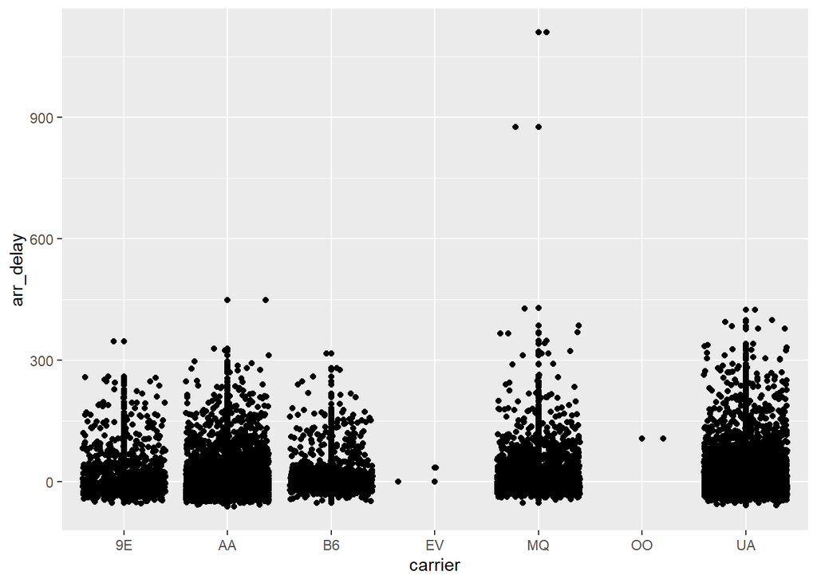

```r
library(ggplot2)
g = ggplot(py$flights, aes(carrier, arr_delay))

g + geom_point() + geom_jitter()
```

### Importing Python modules

`reticulate::import()` allows you to import any Python module and call its functions directly from R.

```r
library(reticulate)
os <- import("os")
os$listdir(".")
```

```
##  [1] "coursera_week2_sarcasm.Rmd" "css"
##  [3] "data"                       "master.html"
##  [5] "master.Rmd"                 "master_files"
##  [7] "meta.tsv"                   "python"
##  [9] "reticulate.Rmd"             "reticulate_files"
## [11] "tf1.Rmd"                    "tf2.Rmd"
## [13] "tf3.Rmd"                    "tf_overview.html"
## [15] "tf_overview.Rmd"            "vecs.tsv"
## [17] "week2_coursera_tf_text.Rmd"
```

### Sourcing Python scripts

You can source any Python script using `reticulate::source_python()` the same way you would `source()` an R script (Python functions and objects defined within the script become directly available to the R session).

```python
import pandas as pd

def read_flights(file):
  flights = pd.read_csv(file)
  flights = flights[flights['dest'] == "ORD"]
  flights = flights[['carrier', 'dep_delay', 'arr_delay']]
  flights = flights.dropna()
  return flights
```

Then you can source the script and call the `read_flights()` function as follows:

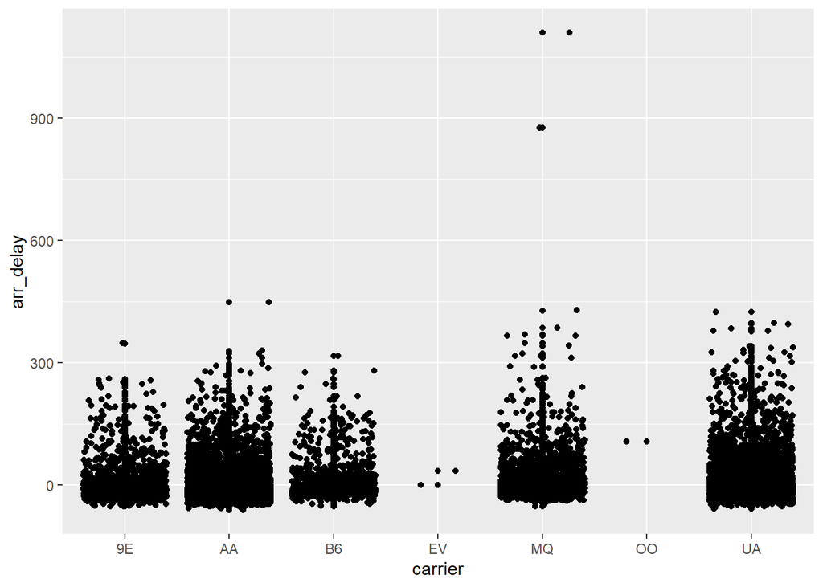

```r
source_python("python/flights.py")
flights <- read_flights("data/flights.csv")

library(ggplot2)
g = ggplot(flights, aes(carrier, arr_delay))

g + geom_point() + geom_jitter()
```

See `?reticulate::source_python()` for documentation and additional details on sourcing Python code.

### Python REPL

If you want to work with Python interactively `reticulate::repl_python()` creates an interactive Python console within R. Objects you create within Python are available to your R session (and vice-versa).

Enter `exit` within the Python REPL to return to the R prompt.

Note that Python code can also access objects from within the R session using the `r` object (e.g. r.flights). See `?reticulate::repl_python()` for the documentation file and additional details on using the embedded Python REPL.

## Type Conversions

When calling into Python, R data types are automatically converted to their equivalent Python types. When values are returned from Python to R they are converted back to R types. Types are converted as follows:

```r
r2py <- tibble::tribble(
~R, ~Python,    ~Examples,
"Single-element vector", "Scalar", '1, 1L, TRUE, "foo"',
'Multi-element vector', "List", "c(1.0, 2.0, 3.0), c(1L, 2L, 3L)",
"List of multiple types", "Tuple", 'list(1L, TRUE, "foo")',
"Named list",   "Dict", "list(a = 1L, b = 2.0), dict(x = x_data)",
"Matrix/Array", "NumPy ndarray", "matrix(c(1,2,3,4), nrow = 2, ncol = 2)",
"Data Frame", "Pandas DataFrame",   'data.frame(x = c(1,2,3), y = c("a", "b", "c"))',
"Function", "Python function",  "function(x) x + 1",
'NULL, TRUE, FALSE',    "None, True, False",    "NULL, TRUE, FALSE"
)

knitr::kable(r2py)
```

| R | Python | Examples |
| --- | --- | --- |
| Single-element vector | Scalar | 1, 1L, TRUE, “foo” |
| Multi-element vector | List | c(1.0, 2.0, 3.0), c(1L, 2L, 3L) |
| List of multiple types | Tuple | list(1L, TRUE, “foo”) |
| Named list | Dict | list(a = 1L, b = 2.0), dict(x = x_data) |
| Matrix/Array | NumPy ndarray | matrix(c(1,2,3,4), nrow = 2, ncol = 2) |
| Data Frame | Pandas DataFrame | data.frame(x = c(1,2,3), y = c(“a”, “b”, “c”)) |
| Function | Python function | function(x) x + 1 |
| NULL, TRUE, FALSE | None, True, False | NULL, TRUE, FALSE |

If a Python object of a custom class is returned then an R reference to that object is returned. You can call methods and access properties of the object just as if it was an instance of an R reference class.

# Tensorflow Overview

Created by the Google Brain team, [**TensorFlow**](https://www.tensorflow.org/) is an open source library for numerical computation and large-scale machine learning. TensorFlow bundles together many machine learning and deep learning (aka neural networking) models and algorithms and makes them useful by way of a common metaphor. Tensorflow uses Python to provide a convenient front-end API for building applications with the framework, while executing those applications in high-performance C++.

TensorFlow allows developers to create dataflow graphs—structures that describe how data moves through a graph, or a series of processing nodes. Each node in the graph represents a mathematical operation, and each connection or edge between nodes is a multidimensional data array, or tensor. Mare specifically as tensor is a mathematical object that is analogous to but more general than a vector, represented by an array of components that are functions of the coordinates of a space.

TensorFlow provides all of this for the programmer by way of the Python language. Python is easy to learn and work with, and provides convenient ways to express how high-level abstractions can be coupled together. Nodes and tensors in TensorFlow are Python objects, and TensorFlow applications are themselves Python applications.

The actual math operations, however, are not performed in Python. The libraries of transformations that are available through TensorFlow are written as high-performance C++ binaries. Python just directs traffic between the pieces, and provides high-level programming abstractions to hook them together.

TensorFlow applications can be run on most any target that’s convenient: a local machine, a cluster in the cloud, iOS and Android devices, CPUs or GPUs. If you use Google’s own cloud, you can run TensorFlow on Google’s custom TensorFlow Processing Unit (TPU) for further acceleration. The resulting models created by TensorFlow, though, can be deployed on most any device where they will be used to serve predictions.

TensorFlow 2.0.0, released in October 2019, revamped the framework in many ways based on user feedback, to make it easier to work with (e.g., by using the relatively simple Keras API for model training) and more performant. Distributed training is easier to run thanks to a new API, and support for TensorFlow Lite makes it possible to deploy models on a greater variety of platforms. However, code written for earlier versions of TensorFlow must be rewritten—sometimes only slightly, sometimes significantly—to take maximum advantage of new TensorFlow 2.0.0 features.

## Benefits

The single biggest benefit TensorFlow provides for machine learning development is abstraction. Instead of dealing with the nitty-gritty details of implementing algorithms, or figuring out proper ways to hitch the output of one function to the input of another, the developer can focus on the overall logic of the application. TensorFlow takes care of the details behind the scenes.

TensorFlow offers additional conveniences for developers who need to debug and gain introspection into TensorFlow apps. The eager execution mode lets you evaluate and modify each graph operation separately and transparently, instead of constructing the entire graph as a single opaque object and evaluating it all at once. The TensorBoard visualization suite lets you inspect and profile the way graphs run by way of an interactive, web-based dashboard.

TensorFlow also gains many advantages from the backing of an A-list commercial outfit in Google. Google has not only fueled the rapid pace of development behind the project, but created many significant offerings around TensorFlow that make it easier to deploy and easier to use: the above-mentioned TPU silicon for accelerated performance in Google’s cloud; an online hub for sharing models created with the framework; in-browser and mobile-friendly incarnations of the framework; and much more.

One caveat: Some details of TensorFlow’s implementation make it hard to obtain totally deterministic model-training results for some training jobs. Sometimes a model trained on one system will vary slightly from a model trained on another, even when they are fed the exact same data. The reasons for this are slippery—e.g., how random numbers are seeded and where, or certain non-deterministic behaviors when using GPUs). That said, it is possible to work around those issues, and TensorFlow’s team is considering more controls to affect determinism in a workflow.

## TensorFlow vs. Competition

TensorFlow competes with a slew of other machine learning frameworks. PyTorch, CNTK, and MXNet are three major frameworks that address many of the same needs. Below I’ve noted where they stand out and come up short against TensorFlow.

- PyTorch, in addition to being built with Python, and has many other similarities to TensorFlow: hardware-accelerated components under the hood, a highly interactive development model that allows for design-as-you-go work, and many useful components already included. PyTorch is generally a better choice for fast development of projects that need to be up and running in a short time, but TensorFlow wins out for larger projects and more complex workflows.
- CNTK, the Microsoft Cognitive Toolkit, like TensorFlow uses a graph structure to describe dataflow, but focuses most on creating deep learning neural networks. CNTK handles many neural network jobs faster, and has a broader set of APIs (Python, C++, C#, Java). But CNTK isn’t currently as easy to learn or deploy as TensorFlow.
- Apache MXNet, adopted by Amazon as the premier deep learning framework on AWS, can scale almost linearly across multiple GPUs and multiple machines. It also supports a broad range of language APIs—Python, C++, Scala, R, JavaScript, Julia, Perl, Go—although its native APIs aren’t as pleasant to work with as TensorFlow’s.

## Getting Started

If you don’t already have the `tensorflow` package for Python installed, you can do so from within R by running the following

```r
reticulate::py_install("tensorflow")
```

or

```r
reticulate::conda_install("tensorflow")
```

Once you’ve installed the `tensorflow` library, import it (aka load it) into your current working environment using the `import` command. Let’s also check the version of `tensorflow` that you have installed. It’s best if you have version `2.0.0` installed now that it has been [**offically released**](https://github.com/tensorflow/tensorflow/releases/tag/v2.0.0)

```python
import tensorflow as tf

print(tf.__version__)
```

```
## 2.0.0
```

At this points let’s also load some other modules that are included with `tensorflow` that we’ll need later.

```python
from tensorflow import keras
from tensorflow.keras.preprocessing.text import Tokenizer
from tensorflow.keras.preprocessing.sequence import pad_sequences
```

# Basic Text Processing Steps with Tensorflow

## Working with Jane Austen’s *Emma*

At this point we need some text to work with. Let’s use the text from the book *Emma* written by Jane Austen, which is made available by the r package `janeaustenr`. We’ll save the text from the book under an object named `emma`.

```r
(emma = janeaustenr::emma[20:30])
```

```
##  [1] "She was the youngest of the two daughters of a most affectionate,"
##  [2] "indulgent father; and had, in consequence of her sister's marriage, been"
##  [3] "mistress of his house from a very early period. Her mother had died"
##  [4] "too long ago for her to have more than an indistinct remembrance of"
##  [5] "her caresses; and her place had been supplied by an excellent woman as"
##  [6] "governess, who had fallen little short of a mother in affection."
##  [7] ""
##  [8] "Sixteen years had Miss Taylor been in Mr. Woodhouse's family, less as a"
##  [9] "governess than a friend, very fond of both daughters, but particularly"
## [10] "of Emma. Between _them_ it was more the intimacy of sisters. Even before"
## [11] "Miss Taylor had ceased to hold the nominal office of governess, the"
```

Next, we create an instance of a tokenizer function using the `Tokenizer` sub-module that we extracted from `tensorflow` earlier. Note that although we use the `Tokenizer`, Tensorflow and Keras provide several ways to encode words. The Tokenizer generates the dictionary of word encodings and creates vectors out of the sentences.

The parameter `num_words = 100` instructs the tokenizer to take the top 100 most used words and just encode those. It’s a shortcut when dealing with a large corpus, and worth experimenting with when training with real data. Note that sometimes the impact of less words can be minimal with respect to training accuracy, but huge in terms of training time.

```python
tokenizer = Tokenizer(num_words = 100,
                      oov_token = "<OOV>")

type(tokenizer)
```

```
## <class 'keras_preprocessing.text.Tokenizer'>
```

As we’ll see, the object `tokenizer` we just created contains other sub-functions that will applied to our text. Also, note that the purpose of the `oov_token = <OOV>` will refer to any token that appears in our training data vocabulary but does not appear in our test data (out of vocabulary). The purpose of this will become clear soon.

Now, we `fit_on_texts()` function that is part of `tokenizer` to builds a dictionary of words from the corpus `emma`. Any inference/prediction will be dependent on the word dictionary to which it uses for comparison

```python
tokenizer.fit_on_texts(r.emma)
```

```python
word_index = tokenizer.word_index

print(word_index)
```

```
## {'<OOV>': 1, 'of': 2, 'had': 3, 'the': 4, 'a': 5, 'her': 6, 'in': 7, 'been': 8, 'governess': 9, 'was': 10, 'daughters': 11, 'and': 12, 'very': 13, 'mother': 14, 'to': 15, 'more': 16, 'than': 17, 'an': 18, 'as': 19, 'miss': 20, 'taylor': 21, 'she': 22, 'youngest': 23, 'two': 24, 'most': 25, 'affec…
```

Next, we need to convert the encoded sentences into lists of value sequences based on the included tokens. This is done using the `texts_to_sequences()` function

```python
sequences = tokenizer.texts_to_sequences(r.emma)

print(sequences)
```

```
## [[22, 10, 4, 23, 2, 4, 24, 11, 2, 5, 25, 26], [27, 28, 12, 3, 7, 29, 2, 6, 30, 31, 8], [32, 2, 33, 34, 35, 5, 13, 36, 37, 6, 14, 3, 38], [39, 40, 41, 42, 6, 15, 43, 16, 17, 18, 44, 45, 2], [6, 46, 12, 6, 47, 3, 8, 48, 49, 18, 50, 51, 19], [9, 52, 3, 53, 54, 55, 2, 5, 14, 7, 56], [], [57, 58, 3, 2…
```

```python
padded = pad_sequences(sequences,
                       padding = "post",
                       maxlen = 12,
                       truncating = "post")

padded
```

```
## array([[22, 10,  4, 23,  2,  4, 24, 11,  2,  5, 25, 26],
##        [27, 28, 12,  3,  7, 29,  2,  6, 30, 31,  8,  0],
##        [32,  2, 33, 34, 35,  5, 13, 36, 37,  6, 14,  3],
##        [39, 40, 41, 42,  6, 15, 43, 16, 17, 18, 44, 45],
##        [ 6, 46, 12,  6, 47,  3,  8, 48, 49, 18, 50, 51],
##        [ 9, 52,  3, 53, 54, 55,  2,  5, 14,  7, 56,  0],
##        [ 0,  0,  0,  0,  0,  0,  0,  0,  0,  0,  0,  0],
##        [57, 58,  3, 20, 21,  8,  7, 59, 60, 61, 62, 19],
##        [ 9, 17,  5, 63, 13, 64,  2, 65, 11, 66, 67,  0],
##        [ 2, 68, 69, 70, 71, 10, 16,  4, 72,  2, 73, 74],
##        [20, 21,  3, 76, 15, 77,  4, 78, 79,  2,  9,  4]])
```

## Working with the Sarcasm Headlines Dataset

```python
import json

DATA = json.load(open("data/Sarcasm_Headlines.json", 'r'))
```

```python
sentences = []
labels = []
urls = []

for item in DATA:
  sentences.append(item['headline'])
  labels.append(item['is_sarcastic'])
  urls.append(item['article_link'])

tokenizer = Tokenizer(num_words = 100, oov_token="<OOV>")

# Builds a dictionary of words from the corpus
# Any inference/prediction will be dependent on the
# word dictionary to which it uses for comparison
tokenizer.fit_on_texts(sentences)

word_index = tokenizer.word_index
print(len(word_index))
#print(word_index)
```

```
## 24575
```

```python
sequences = tokenizer.texts_to_sequences(sentences)

# padded out sequences into a matrix
padded = pad_sequences(sequences,
                       padding = "post", # move padding to the end of the matrix
                       truncating = "post")

print(sentences[2])
```

```
## mom starting to fear son's web series closest thing she will have to grandchild
```

```python
print(padded[2])
```

```
## [ 1  1  2  1  1  1  1  1  1  1 37 46  2  1  0  0  0  0  0  0  0  0  0  0
##   0  0  0  0  0  0  0  0  0  0  0  0  0  0  0  0]
```

```python
print(padded.shape)
```

```
## (18350, 40)
```